# R Package for Multiple Factor Analysis

## Introduction of Mutiple Factor Analysis (MFA)

Multiple factor analysis (MFA) is used for analyzing multiple data tables that measure sets of variables collected on the same observations.

There are two main steps in MFA:

1. Conduct PCA on each data table (or block, subtable), and ‘normalizes’ each data table by dividing all its elements by the first singular value obtained from its PCA
2. Concatenate all the normalized data tables into a grand data table, and conduct generalized PCA on this grand table.

The outcome of MFA analysis includes: eigenvalues, factor score for obeservations, partial factor score for each data table, and loadings for variables.

## Data Set: wine.csv

The data are from a (fictitious) wine tasting experiment.

Each of the 10 experts were asked to evaluate the 12 wines, in terms of four basic variables and personalized additional variables.

The structure of the dataset, or grand table, can be described as:

- The grand table is a concatenation of 10 subtables, representing the data for each experts
- Rows are the data for one specific observation (ie wine)
- Columns are the data for one specific variable

## Main Function to Compute MFA:

`mfa_gen(data, sets, ncomps = NULL, center = TRUE, scale = TRUE)`

The argument includes:

- `data`: the grand-table containing all blocks
- `sets`: a list containing the indexes for each block
- `ncomps`: number of principle components to keep (if not provided, all principle components are kept)
- `center`: either a logical value or a numeric vector of length equal to the number of columns of `data`
- `scale`: either a logical value or a numeric vector of length equal to the number of columns of `data`

```r
wine <- mfa_gen(datanum, sets, ncomps = 2)
```

## Main Function to Compute MFA:

The output of `mfa_gen` function is a S3 `mfa` object containing eigenvalues, factor score, partial factor scores, loadings, the matrix `A` and `sets` (from the input). We stored `A` to compute the contribution of variables in later function called `contri_var`.

For example, we can extract the factor score from the `mfa` object:

```r
wine$FactorScore
```

```
##              [,1]        [,2]
##  [1,] -0.98020575  0.16325474
##  [2,] -0.80886515  0.03262348
##  [3,] -0.76100584 -0.45418702
##  [4,] -1.11498367 -0.16586214
##  [5,]  1.37275684 -0.12838880
##  [6,]  1.26401538 -0.10813651
##  [7,]  0.80828274  0.20466790
##  [8,]  0.92534231  0.40775212
##  [9,] -0.66895382  0.36852275
## [10,]  0.07316059 -0.75677932
## [11,] -0.47610885  0.51276640
## [12,]  0.36656519 -0.07623359
```

## Print Method:

`print(object, subtable = NULL, ...)`

The print method is designed to print out:

- Eigenvalues of an MFA object
- Partial factor scores of a subtable if the user specifies the index of the subtable as the argument `subtable`
- By default, `subtable = NULL`, and the partial factore scores are not presented.

```r
# print the eigenvalues
print(wine)
```

```
## Eigenvalues (listed in the order of components)
##     1     2
##  0.77 0.123
```

## Print Method:

`print(object, subtable = NULL, ...)`

```r
# print the eigenvalues and the partical factor scores for the 6th subtable
print(wine, subtable = 6)
```

```
## Eigenvalues (listed in the order of components)
##     1     2
##  0.77 0.123
##
## Partial Factor Score Matrix for Assessor No.6
##             1           2
## 1  -0.9479286 -0.19829441
## 2  -0.3816379  0.13786602
## 3  -1.0089076 -0.16384454
## 4  -1.3414628 -0.06470492
## 5   1.6164066  0.15773905
## 6   0.8585928 -0.16041799
## 7   0.9258800  0.20949925
## 8   0.9741298  0.51401719
## 9  -0.8547100  0.22939746
## 10  0.3477934 -0.83698437
## 11 -0.3923523  0.89872062
## 12  0.2041968 -0.72299336
```

## Plot Method:

`plot(mfa, dim1 = 1, dim2 = 2, type = 1, scale_x = 1, scale_y = 1, text = NULL, cat = NULL, var = NULL)`

Given the indices of extracted PCs as 2 dimensions (argument `dim1`, `dim2`), the plot method plots graphs of:

- factor scores (the compromise of the tables) if argument `type = 1`
- partial factor scores if argument `type = 2`
- variable loadings if argument `type = 3`
- partial factor scores and variable loadings if argument `type = 4`

To adjust the scale of the graphs, change the value of arguments `scale_x`, `scale_y`.

The `text` argument allows users to define lables for variables as a vector.

The `cat` argument allows users to define categories to group the observations as a vector.

The `var` argument allows users to indicate the graphs of specific subtables as a numerical vector of the indices of subtables.

## Examples:

Plot the compromise of the tables (type = 1) :

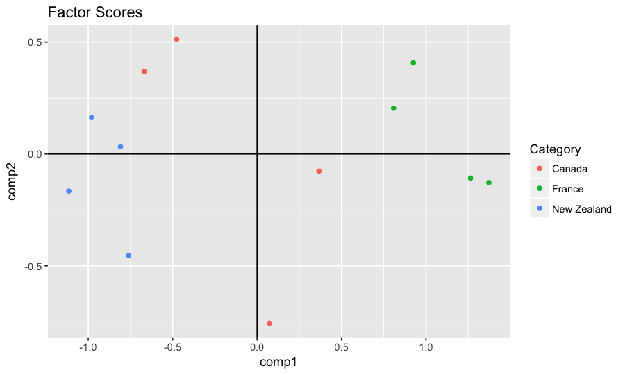

```r
# define the categories to group the observations
cat <- list("New Zealand" = 1:4, "France" = 5:8, "Canada" = 9:12)

plot(mfa = wine, cat = cat)
```

Plot the partial factor scores (type = 2) for the 8th subtable with the categories to group the observations:

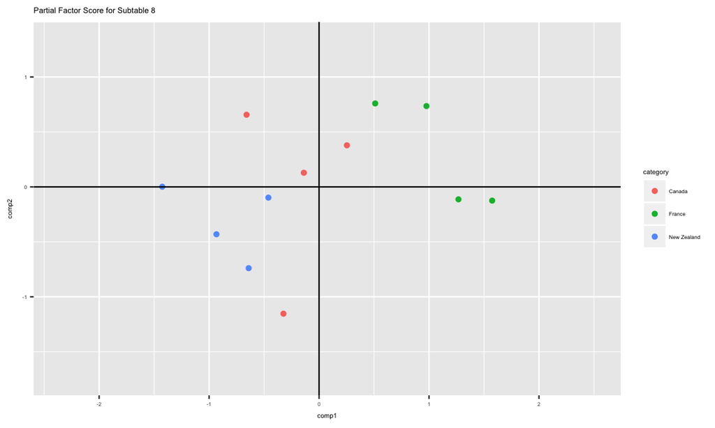

```r
# define the categories to group the observations
plot(mfa = wine, dim1 = 1, dim2 = 2, type = 2, cat = cat, var = 8)
```

Plot the variable loadings (type = 3) for the 3rd subtable without labels for variables:

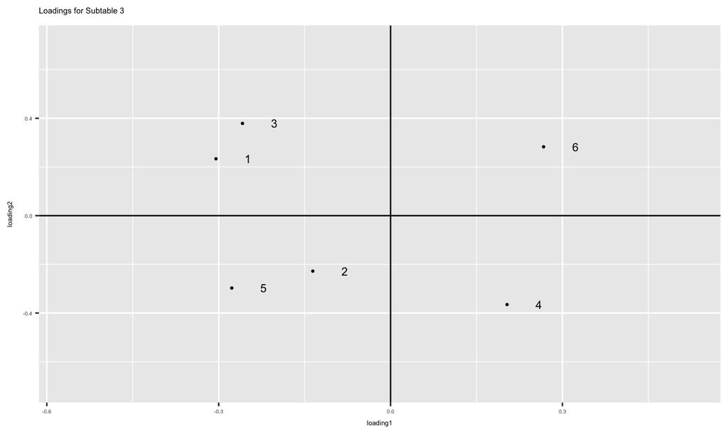

```r
plot(mfa = wine, type = 3, var = 3)
```

Plot the partial factor scores and variable loadings (type = 4) for the 1st subtable with the categories to group the observations:

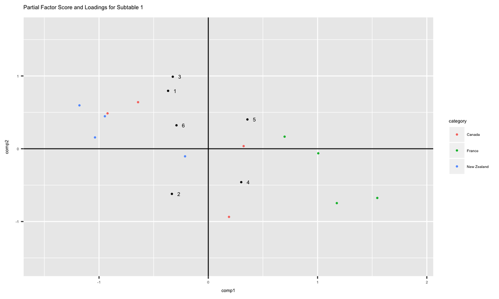

```r
plot(mfa = wine, type = 4, cat = cat, scale_x = 1/0.8, scale_y = 1/0.4, var = 1)
```

## Eigenvalues Method:

`eigenval(x)`

It is the method applied to the target data set that display a table including informations of singular values, eigenvalues, cumulative, percentage of intertia, cumulative percentage of inertia for the extracted components.

```r
eigenval(wine)
```

```
##                          1       2
## singular             0.877   0.351
## eigenvalue           0.770   0.123
## cumulative           0.770   0.893
## intertia            86.000  14.000
## cumulative.intertia 86.000 100.000
```

## Contributions Method:

`contri_obs(x)`

The `contri_obs` method calculates and present the contribution of observations to the extracted components (dimensions). The [i,j] element of the printed matrix is the contribution of the ith observation to the jth component. The equation is the following:

\(ctr_{i,l} = \displaystyle{\frac{m_i \times f^2_{i,l}}{\lambda_l}}\)

Here is how to use it:

```r
head(contri_obs(wine))
```

[output not shown]

## Contributions Method:

`contri_var(x)`

The `contri_var` method calculates and present the contribution of variables to the extracted components (dimensions). The [i,j] element of the printed matrix is the contribution of the ith variable to the jth component. The equation is the following:

\(ctr_{j,l} = \alpha_j \times q^2_{j,l}\)

Here is how to use it:

```r
head(contri_var(wine))
```

```
##            [,1]        [,2]
## [1,] 0.02088509 0.024412753
## [2,] 0.01712210 0.014842367
## [3,] 0.01628702 0.037770575
## [4,] 0.01401010 0.008126163
## [5,] 0.01975609 0.006248678
## [6,] 0.01307229 0.004001629
```

## Contributions Method:

`contri_table(x)`

The `contri_table` method calculates and present the contribution of subtables to the extracted components (dimensions). The [i,j] element of the printed matrix is the contribution of the ith subtable to the jth component. The equation is the following:

\(ctr_{k,l} = \sum_{j}^{J_{[k]}} ctr_{j,l}\)

Here is how to use it:

```r
head(contri_table(wine))
```

```
##            [,1]       [,2]
## [1,] 0.10113269 0.09540216
## [2,] 0.10005784 0.06849423
## [3,] 0.10105112 0.15169038
## [4,] 0.09641740 0.04858138
## [5,] 0.09752272 0.06349839
## [6,] 0.10076960 0.10444939
```

## Coefficient Function:

RV is the function to compute Escoufier's \(R_V\) coefficient, which reflecst the amount of variance shared by two matrices. The equation to compute \(R_V\) coefficient between data table \(k\) and \(k'\) is

\(R_{Vk,k'} = \frac{\operatorname{trace} \left( \left(X_{[k]} X^{T}_{[k]}\right) \times \left(X_{[k']} X^{T}_{[k']}\right)\right)}{\sqrt{\operatorname{trace} \left(\left(X_{[k]} X^{T}_{[k]}\right) \times \left(X_{[k]} X^{T}_{[k]}\right)\right) \times \operatorname{trace} \left(\left(X_{[k']} X^{T}_{[k']}\right) \times \left(X_{[k']} X^{T}_{[k']}\right)\right)}}\)

`RV(table1,table2)`

RV(table1, table2) takes input of two tables, and compute the \(R_V\) coefficent.

```r
RV(datanum[,1:6],datanum[,7:12])
```

```
## [1] 0.9701797
```

## Coefficient Function:

`RV_table(dataset, sets)`

RV_table(dataset, sets) takes input of a data set and a list with sets of variables, and returns a matrix of \(R_V\) coefficients. Each element of the matrix corresponds to the \(R_V\) coefficient of each pair of tables.

```r
RV_table(datanum,sets=list(1:6,7:50,50:53))
```

```
##           [,1]      [,2]      [,3]
## [1,] 1.0000000 0.9837895 0.9857907
## [2,] 0.9837895 1.0000000 0.9892394
## [3,] 0.9857907 0.9892394 1.0000000
```

## \(L_g\) Coefficient Function:

`Lg_table(dataset, sets)`

- The \(L_g\) coefficient is another coefficient to evaluate the similarity between two tables.
- This coefficient reflects the MFA normalization and takes positive values.
- The detailed formula is:

\(L_{g(k,k')} = \operatorname{trace} \left( \left(X_{[k]} X^{T}_{[k]}\right) \times \left(X_{[k']} X^{T}_{[k']}\right)\right) \times \left(\alpha_{k} \times \alpha_{k'}\right)\)

where \(X_{[k]}\) and \(X_{[k']}\) are the data of two subtables, and \(\alpha_{k}\) and \(\alpha_{k'}\) are their corresponding inversed first squared singular value.

The following is how to use it:

```r
Lg_table(datanum, sets = list(sets[[1]], sets[[2]]))
```

```
##           [,1]      [,2]
## [1,] 1.0131412 0.9777692
## [2,] 0.9777692 1.0025323
```

## Bootstrap Function:

`bootstrap(L,userset,dataset,ncomp)`

The arguments includes:

`L`: the size of bootstrap `dataset`: the grand-table containing all blocks `userset`: a list containing the indexes for each block `ncomp`: number of principle components to keep (if not provided, all principle components are kept)

The output of `bootstrap` function is the bootstrap ratio.

## Bootstrap Function:

Here is how to perform 1000 bootstrap and get the bootstrap ratios of the 12 wines.

```r
bootstrap(L = 1000, userset = sets, dataset = datanum, ncomp = 2)
```

```
##             [,1]       [,2]
##  [1,] -24.804184  1.3311386
##  [2,] -10.247757  0.3261701
##  [3,]  -8.605762 -5.1032181
##  [4,] -16.348030 -1.0635556
##  [5,]  20.211070 -1.0687435
##  [6,]  15.071962 -0.9347048
##  [7,]   8.273319  2.1033786
##  [8,]  16.267459  3.5246584
##  [9,]  -6.788806  2.5747346
## [10,]   1.028035 -5.4167929
## [11,]  -5.936393  6.6881669
## [12,]   5.127176 -0.6371562
```

## Shiny App:

Output includes:

- Bar-chart for eigenvalues
- Scatter plot for Factor Scores
- Scatter plot for Partial Factor Scores
- Scatter plot for Loadings
- Scatter plot for Partial Factor Scores together with Loadings

Default dataset: wine dataset

The shiny app is published on `https://chengli.shinyapps.io/r_243_final_shiny/`.